# PRACTICA PISA

# Cross Validation

Dividimos nuestra base en 2 partes como bien es sabido, train y test. Se hace de nuevo sin embargo en este caso dudamos de su utilidad dad que estamos trabajando sobre una base da datos que posee muy pocas observaciones.

```r
set.seed(1234)
pisa_split <- initial_split(pisa, prop =.8, strata = "overall")
pisa_train <- training(pisa_split)
pisa_test <- testing(pisa_split)
```

Incluimos el mejor de los 3 modelos extraídos anteriormente

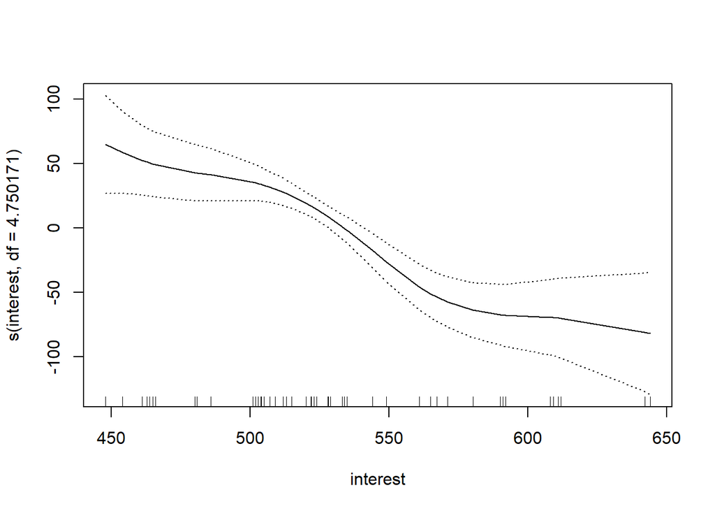

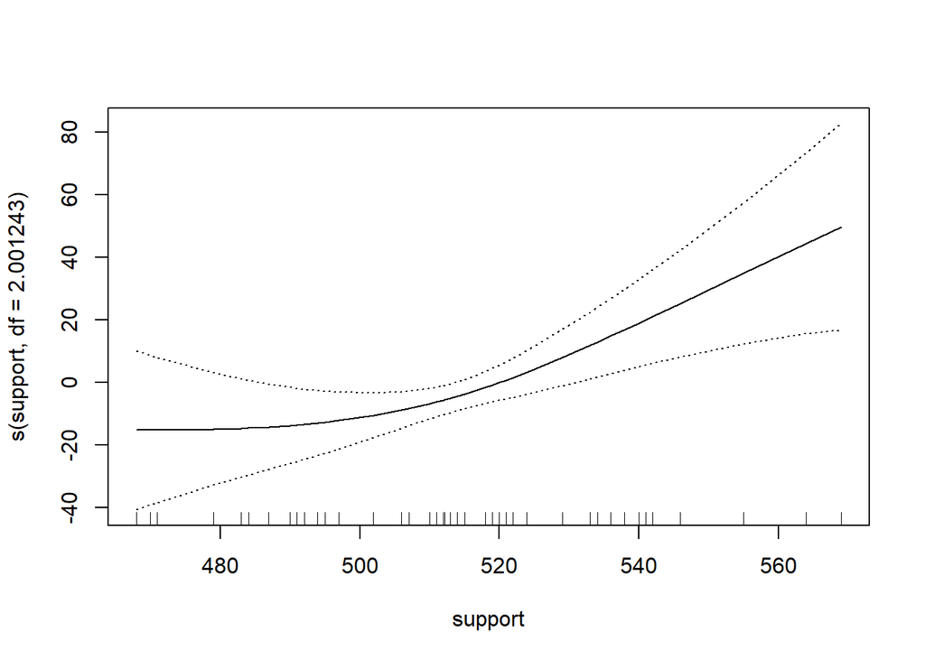

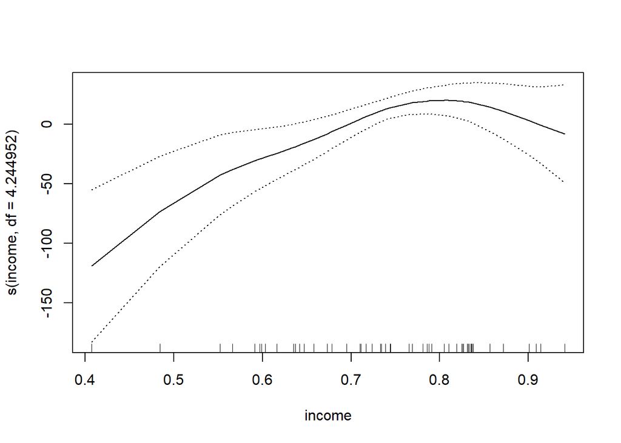

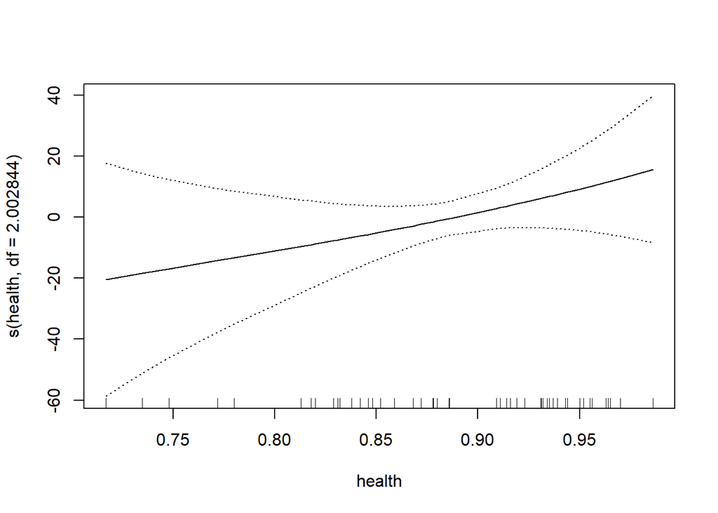

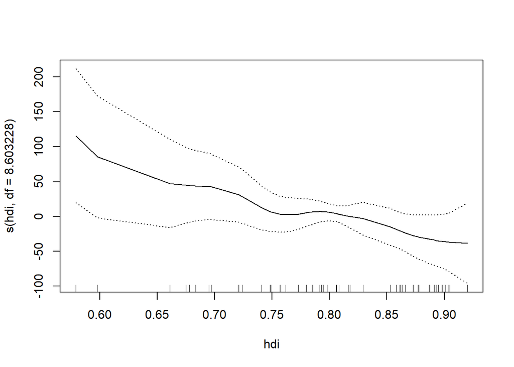

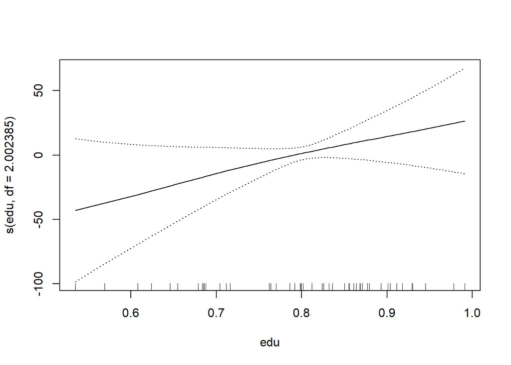

```r
gam_1t <- gam(overall ~ s(interest, df= 4.750171) + s(support, df = 2.001243) + s(income, df  = 4.244952) + s(health, df = 2.002844) + s(hdi, df=8.603228) + s(edu, df=2.002385) , data=pisa_train)
plot(gam_1t,se=TRUE, col='black')
```

```r
summary(gam_1t)
```

```
##
## Call: gam(formula = overall ~ s(interest, df = 4.750171) + s(support,
##     df = 2.001243) + s(income, df = 4.244952) + s(health, df = 2.002844) +
##     s(hdi, df = 8.603228) + s(edu, df = 2.002385), data = pisa_train)
## Deviance Residuals:
##     Min      1Q  Median      3Q     Max
## -55.831  -9.308   3.140  10.194  35.809
##
## (Dispersion Parameter for gaussian family taken to be 519.5044)
##
##     Null Deviance: 147679.3 on 53 degrees of freedom
## Residual Deviance: 15271.12 on 29.3955 degrees of freedom
## AIC: 509.2699
##
## Number of Local Scoring Iterations: NA
##
## Anova for Parametric Effects
##                                Df Sum Sq Mean Sq  F value    Pr(>F)
## s(interest, df = 4.750171)  1.000  82169   82169 158.1671 2.338e-13 ***
## s(support, df = 2.001243)   1.000   6327    6327  12.1794  0.001546 **
## s(income, df = 4.244952)    1.000   2150    2150   4.1381  0.051040 .
## s(health, df = 2.002844)    1.000     10      10   0.0193  0.890457
## s(hdi, df = 8.603228)       1.000    811     811   1.5608  0.221409
## s(edu, df = 2.002385)       1.000   1209    1209   2.3271  0.137824
## Residuals                  29.396  15271     520
## ---
## Signif. codes:  0 '***' 0.001 '**' 0.01 '*' 0.05 '.' 0.1 ' ' 1
##
## Anova for Nonparametric Effects
##                            Npar Df Npar F    Pr(F)
## (Intercept)
## s(interest, df = 4.750171)     3.7 4.5342 0.006458 **
## s(support, df = 2.001243)      1.0 6.4953 0.016262 *
## s(income, df = 4.244952)       3.2 6.2783 0.001621 **
## s(health, df = 2.002844)       1.0 0.2004 0.658383
## s(hdi, df = 8.603228)          7.6 0.8599 0.555697
## s(edu, df = 2.002385)          1.0 0.4348 0.515249
## ---
## Signif. codes:  0 '***' 0.001 '**' 0.01 '*' 0.05 '.' 0.1 ' ' 1
```

Se pueba sin incluir los grados de libertad incluidos al principio en las variables health, edu y hdi

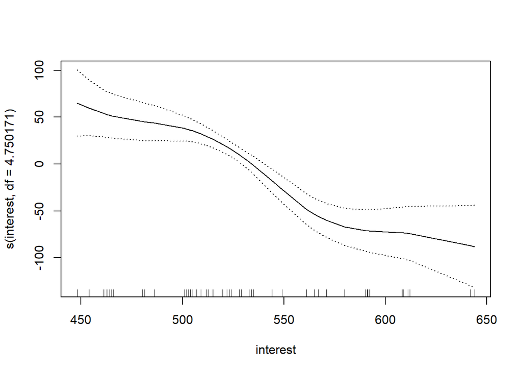

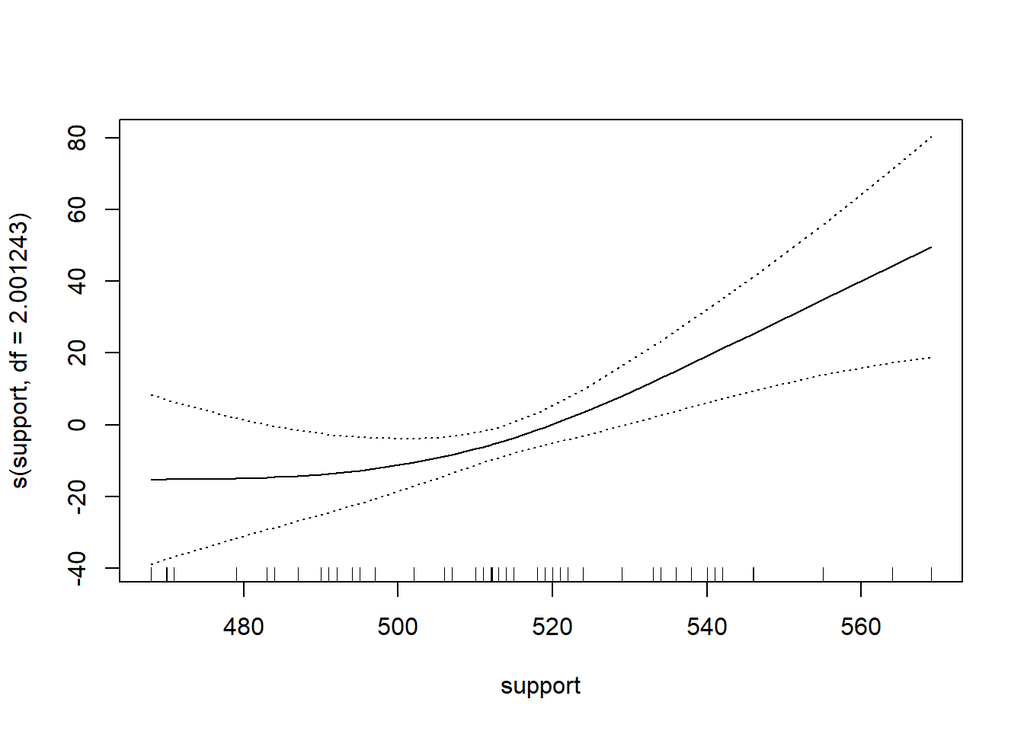

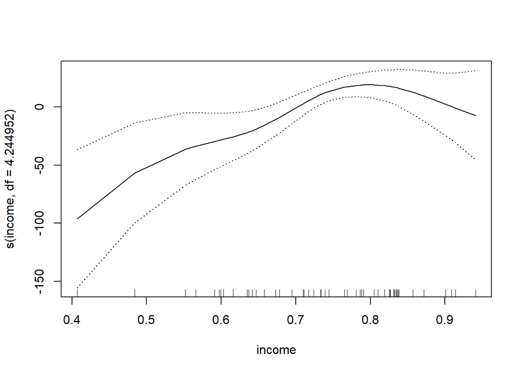

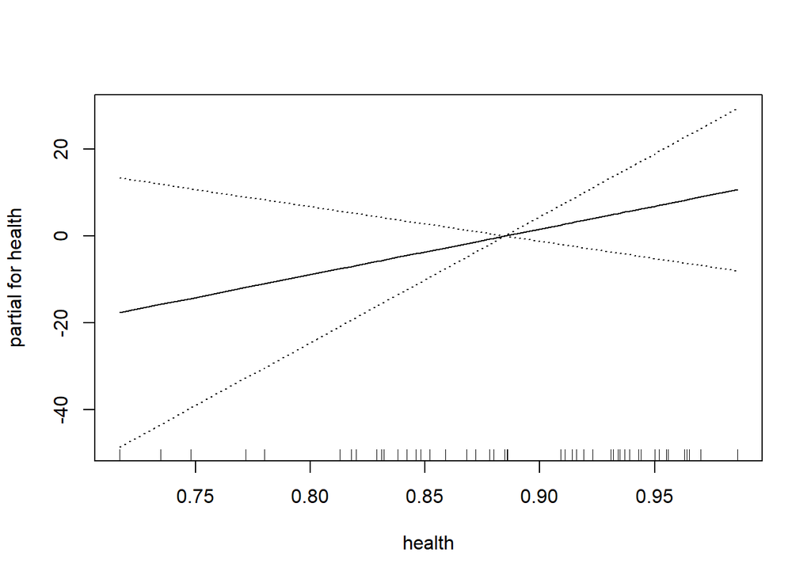

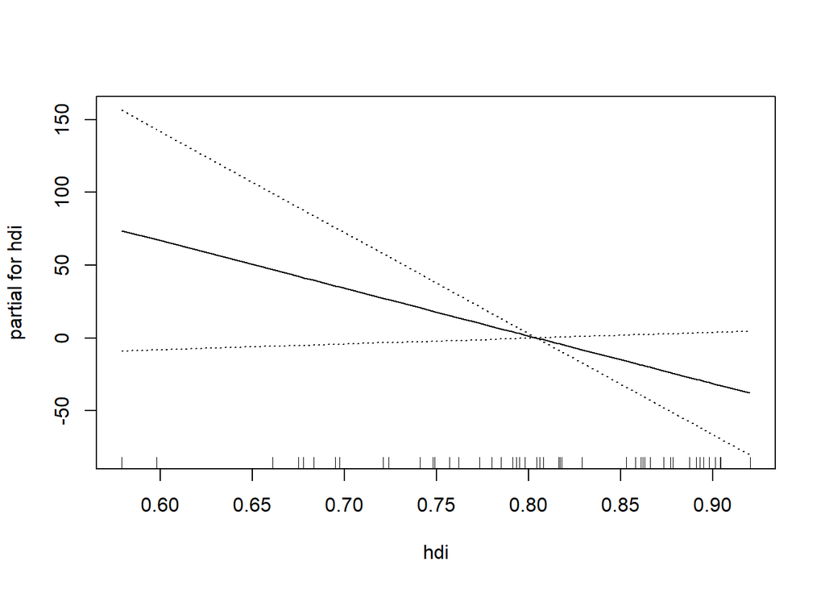

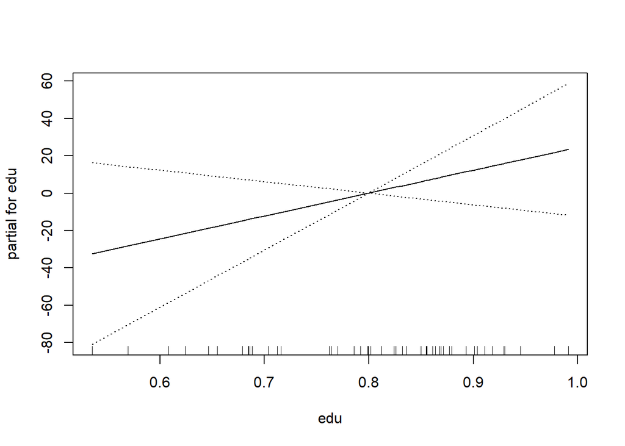

```r
gam_2t <- gam(overall ~ s(interest, df= 4.750171) + s(support, df = 2.001243) + s(income, df  = 4.244952) + health + hdi + edu, data=pisa_train)
plot(gam_2t,se=TRUE, col='black')
```

```r
summary(gam_2t)
```

```
##
## Call: gam(formula = overall ~ s(interest, df = 4.750171) + s(support,
##     df = 2.001243) + s(income, df = 4.244952) + health + hdi +
##     edu, data = pisa_train)
## Deviance Residuals:
##     Min      1Q  Median      3Q     Max
## -58.530 -10.723   3.089   9.267  36.739
##
## (Dispersion Parameter for gaussian family taken to be 450.9639)
##
##     Null Deviance: 147679.3 on 53 degrees of freedom
## Residual Deviance: 17589.35 on 39.0039 degrees of freedom
## AIC: 497.6851
##
## Number of Local Scoring Iterations: NA
##
## Anova for Parametric Effects
##                                Df Sum Sq Mean Sq  F value    Pr(>F)
## s(interest, df = 4.750171)  1.000  85879   85879 190.4333 < 2.2e-16 ***
## s(support, df = 2.001243)   1.000   5969    5969  13.2358 0.0007943 ***
## s(income, df = 4.244952)    1.000   1740    1740   3.8582 0.0566567 .
## health                      1.000      0       0   0.0004 0.9841522
## hdi                         1.000    712     712   1.5786 0.2164361
## edu                         1.000    800     800   1.7735 0.1906768
## Residuals                  39.004  17589     451
## ---
## Signif. codes:  0 '***' 0.001 '**' 0.01 '*' 0.05 '.' 0.1 ' ' 1
##
## Anova for Nonparametric Effects
##                            Npar Df Npar F    Pr(F)
## (Intercept)
## s(interest, df = 4.750171)     3.7 5.8704 0.001050 **
## s(support, df = 2.001243)      1.0 7.4052 0.009646 **
## s(income, df = 4.244952)       3.2 6.0680 0.001348 **
## health
## hdi
## edu
## ---
## Signif. codes:  0 '***' 0.001 '**' 0.01 '*' 0.05 '.' 0.1 ' ' 1
```